# Simulation-Based Power Analysis

Part 0: R básico — primer para los que no usan R con frecuencia

Author

Affiliation

Filip Andras, David López-García & David Sánchez Casasola

Centro de Investigación Mente Cerebro y Comportamiento (CIMCYC), Universidad de Granada

Published

26 May 2026

**Tip**

**¿Para quién es este documento?** Para quienes no usan R con frecuencia y necesitan un repaso antes de empezar el curso. Si ya manejas variables, vectores, data frames y la consola de RStudio, puedes saltar directamente a la Parte 1.

# 1 La consola y el entorno

La **consola R** es la interfaz interactiva donde se escriben y ejecutan comandos. Los resultados aparecen justo debajo del comando.

El **environment** es el espacio de trabajo donde se almacenan los objetos que creas durante la sesión (variables, funciones, datos). En RStudio lo verás arriba a la derecha — cada vez que asignes algo a un nombre, aparece allí.

Lo que estás leyendo es un documento Quarto. Dentro de él hay **chunks de código** que se ejecutan al hacer clic en el botón verde (▶) o con `Cmd + Enter` (Mac) / `Ctrl + Enter` (Windows/Linux).

# 2 Variables

Una variable es simplemente un **nombre que apunta a un valor**. Se crea asignando un valor a un nombre con el operador `<-`:

```r
# Esto crea una variable llamada "x" que contiene el valor 10
x <- 10

# Para mostrar el valor que contiene, basta con escribir su nombre:
x
```

```
[1] 10
```

Puedes reasignar el valor de una variable cuando quieras — el último valor asignado es el que queda:

```r
nsim <- 10000   # primer valor
nsim <- 1000    # lo sobrescribimos

nsim            # ahora vale 1000
```

```
[1] 1000
```

**Note**

**Atajo en RStudio**: `Option + -` (Mac) o `Alt + -` (Windows/Linux) inserta `<-` automáticamente.

# 3 Vectores

Un **vector** es una secuencia de elementos del mismo tipo (números, caracteres o valores lógicos). Se crea con la función `c()` (de *concatenate*):

```r
mi_vector <- c(1, 2, 3, 4, 5)
mi_vector
```

```
[1] 1 2 3 4 5
```

R tiene funciones para resumir un vector. Algunas que usaremos mucho:

**mean()**

```r
mean(mi_vector)
```

```
[1] 3
```

**sd()**

```r
sd(mi_vector)
```

```
[1] 1.581139
```

**length()**

```r
length(mi_vector)
```

```
[1] 5
```

## 3.1 Repetir un vector con `rep()`

```r
mi_vector_repetido <- rep(mi_vector, times = 2)
mi_vector_repetido
```

```
 [1] 1 2 3 4 5 1 2 3 4 5
```

El argumento `each` repite cada elemento individualmente en lugar de la secuencia completa — comparemos:

**times = 2**

```r
rep(c("a", "b", "c"), times = 2)
```

```
[1] "a" "b" "c" "a" "b" "c"
```

```r
# repite la secuencia completa dos veces: a b c a b c
```

**each = 2**

```r
rep(c("a", "b", "c"), each = 2)
```

```
[1] "a" "a" "b" "b" "c" "c"
```

```r
# repite cada elemento dos veces: a a b b c c
```

## 3.2 Crear un vector vacío

A veces necesitamos un vector vacío que rellenaremos dentro de un bucle. La forma estándar:

```r
vector_vacio <- rep(NA, nsim)   # nsim posiciones todas con valor NA

head(vector_vacio)              # muestra los primeros 6 elementos
```

```
[1] NA NA NA NA NA NA
```

```r
length(vector_vacio)            # verifica que tiene nsim elementos
```

```
[1] 1000
```

# 4 Data frames

Un **data frame** es como una tabla: tiene filas (observaciones) y columnas (variables). Es la estructura más común para almacenar datos en R.

Para construir uno desde cero, primero creamos los vectores que serán las columnas:

```r
# Vector de IDs de sujetos: del 1 al 20
subj <- 1:20

# Vector con las dos condiciones del experimento:
condicion <- c("control", "tratamiento")

# Para que cada sujeto aparezca en una condición, repetimos cada una 10 veces:
condicion_repetida <- rep(condicion, each = 10)
condicion_repetida
```

```
 [1] "control"     "control"     "control"     "control"     "control"
 [6] "control"     "control"     "control"     "control"     "control"
[11] "tratamiento" "tratamiento" "tratamiento" "tratamiento" "tratamiento"
[16] "tratamiento" "tratamiento" "tratamiento" "tratamiento" "tratamiento"
```

Ahora juntamos los vectores en un data frame con `data.frame()`:

```r
dat <- data.frame(subj      = subj,
                  condicion = condicion_repetida)

dat
```

```
   subj   condicion
1     1     control
2     2     control
3     3     control
4     4     control
5     5     control
6     6     control
7     7     control
8     8     control
9     9     control
10   10     control
11   11 tratamiento
12   12 tratamiento
13   13 tratamiento
14   14 tratamiento
15   15 tratamiento
16   16 tratamiento
17   17 tratamiento
18   18 tratamiento
19   19 tratamiento
20   20 tratamiento
```

## 4.1 Acceder a columnas con `$`

Para acceder a una columna específica de un data frame, se usa el operador `$`:

```r
dat$subj         # toda la columna subj
```

```
 [1]  1  2  3  4  5  6  7  8  9 10 11 12 13 14 15 16 17 18 19 20
```

```r
dat$condicion    # toda la columna condicion
```

```
 [1] "control"     "control"     "control"     "control"     "control"
 [6] "control"     "control"     "control"     "control"     "control"
[11] "tratamiento" "tratamiento" "tratamiento" "tratamiento" "tratamiento"
[16] "tratamiento" "tratamiento" "tratamiento" "tratamiento" "tratamiento"
```

## 4.2 Crear una columna nueva

La forma más directa: asignar un vector nuevo a un nombre que aún no existe. La función `ifelse()` es útil para crear columnas según una condición:

```r
# Si la condición es "control", asigna -0.5; si no, asigna +0.5
dat$cond.cod <- ifelse(dat$condicion == "control", -0.5, 0.5)

head(dat)
```

```
  subj condicion cond.cod
1    1   control     -0.5
2    2   control     -0.5
3    3   control     -0.5
4    4   control     -0.5
5    5   control     -0.5
6    6   control     -0.5
```

## 4.3 Verificar el diseño con `xtabs()`

`xtabs()` cuenta cuántas observaciones hay en cada combinación de variables — muy útil para verificar que un data frame tiene la estructura esperada:

```r
# ¿Cuántos sujetos hay en cada condición?
xtabs(~ condicion, data = dat)
```

```
condicion
    control tratamiento
         10          10
```

```r
# ¿Y por la combinación condición × cond.cod?
xtabs(~ condicion + cond.cod, data = dat)
```

```
             cond.cod
condicion     -0.5 0.5
  control       10   0
  tratamiento    0  10
```

# 5 Matrices

Una **matriz** es una estructura bidimensional con filas y columnas, donde todos los elementos son del mismo tipo. Se crea con `matrix()`:

```r
mi_matriz <- matrix(c("a", "b", "c", "d", "e", "f"), ncol = 3)
mi_matriz
```

```
     [,1] [,2] [,3]
[1,] "a"  "c"  "e"
[2,] "b"  "d"  "f"
```

## 5.1 Acceder a elementos con `[fila, columna]`

**Un elemento**

```r
# Elemento en la primera fila, primera columna:
mi_matriz[1, 1]
```

```
[1] "a"
```

```r
# Elemento en la segunda fila, tercera columna:
mi_matriz[2, 3]
```

```
[1] "f"
```

**Toda una fila**

```r
# Toda la primera fila (deja la columna en blanco):
mi_matriz[1, ]
```

```
[1] "a" "c" "e"
```

**Toda una columna**

```r
# Toda la segunda columna (deja la fila en blanco):
mi_matriz[, 2]
```

```
[1] "c" "d"
```

# 6 Distribuciones aleatorias

R tiene funciones para generar números aleatorios desde muchas distribuciones. Usaremos sobre todo dos en el curso:

**Normal con rnorm()**

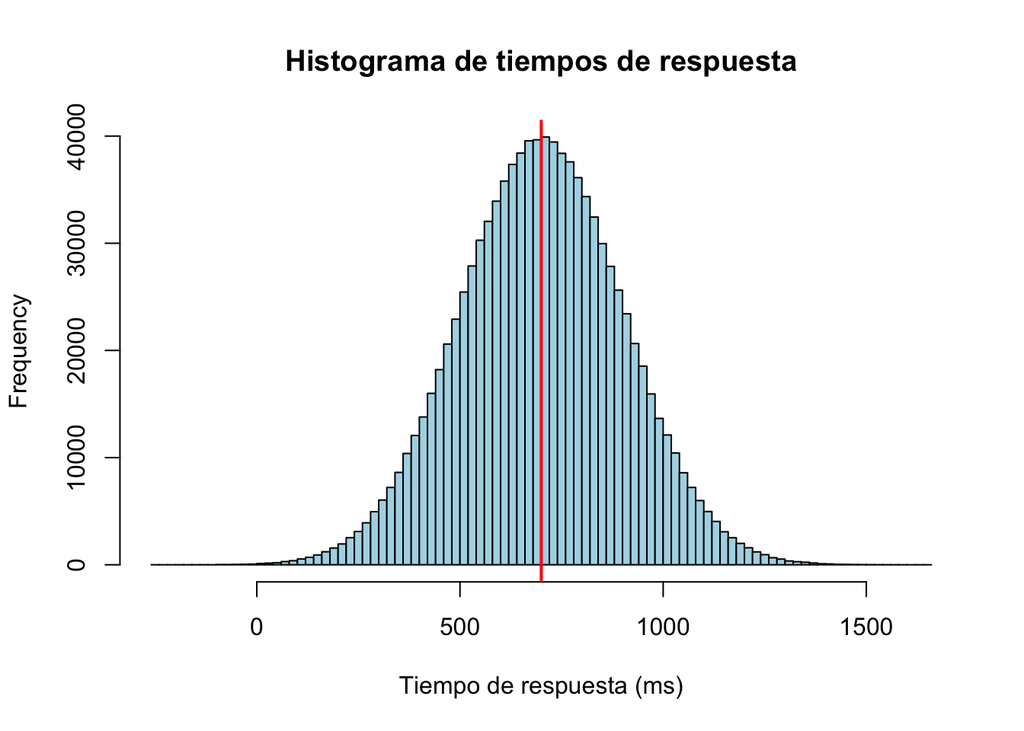

Histograma de 1.000.000 de tiempos de respuesta simulados desde una distribución normal con media 700 y SD 200. La línea roja marca la media teórica.

```r
# Genera un millón de tiempos de respuesta normalmente distribuidos
tiempos_respuesta <- rnorm(1000000, mean = 700, sd = 200)

hist(tiempos_respuesta, breaks = 100,
     main = "Histograma de tiempos de respuesta",
     xlab = "Tiempo de respuesta (ms)",
     col  = "lightblue")

# Línea vertical en la media teórica
abline(v = 700, col = "red", lwd = 2)
```

**Log-normal con rlnorm()**

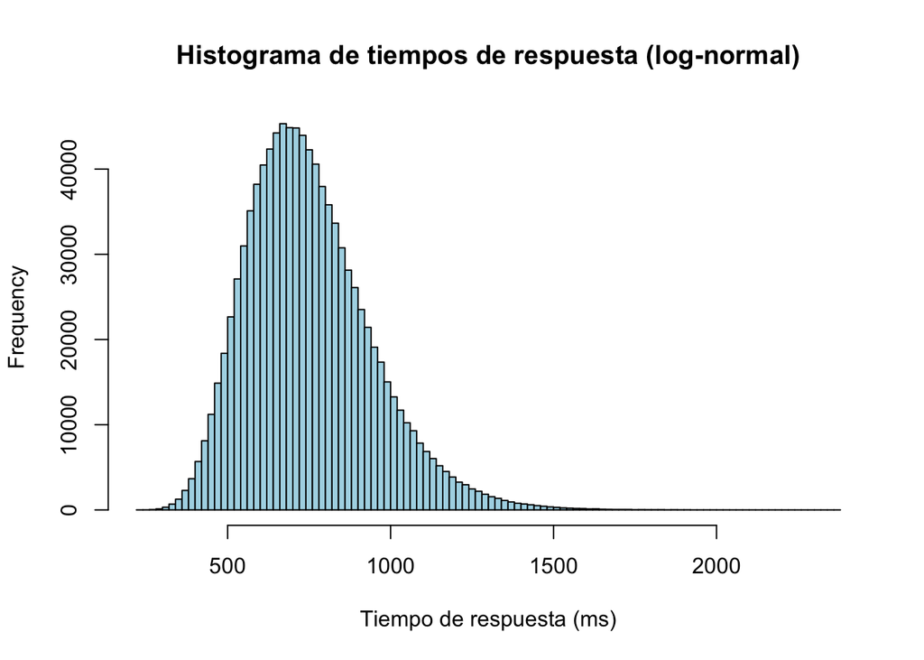

Histograma de 1.000.000 de tiempos de respuesta simulados desde una distribución log-normal. Asimétrica a la derecha, con valores siempre positivos — más realista para tiempos de respuesta.

```r
# Genera un millón de tiempos de respuesta log-normalmente distribuidos
tiempos_respuesta <- rlnorm(1000000, mean = 6.59, sd = 0.25)

hist(tiempos_respuesta, breaks = 100,
     main = "Histograma de tiempos de respuesta (log-normal)",
     xlab = "Tiempo de respuesta (ms)",
     col  = "lightblue")
```

**Note**

La distribución normal puede generar valores negativos, lo cual es imposible para un tiempo de respuesta. La log-normal es **siempre positiva** y **asimétrica a la derecha** — más realista. Volveremos a esto en la Parte 7.

## 6.1 Reproducibilidad con `set.seed()`

Los números aleatorios en R son **pseudo-aleatorios**: dada una semilla inicial, la secuencia es siempre la misma. Esto es muy útil porque te permite reproducir exactamente los mismos resultados.

```r
set.seed(42)
rnorm(5, mean = 0, sd = 1)
```

```
[1]  1.3709584 -0.5646982  0.3631284  0.6328626  0.4042683
```

# 7 Ayuda integrada

Para consultar la documentación de cualquier función:

```r
help(rnorm)   # abre la ayuda de rnorm()
?rnorm        # forma corta equivalente
```

La pestaña **Help** de RStudio se abrirá con los argumentos, ejemplos y detalles de la función.

# 8 Librerías (paquetes)

R viene con muchas funciones de fábrica, pero las más interesantes están en **paquetes** que se instalan una sola vez y se cargan en cada sesión:

```r
# Instalar ggplot2 (necesario solo la primera vez):
install.packages("ggplot2")
```

```r
# Cargar ggplot2 (necesario cada vez que abres RStudio):
library(ggplot2)
```

En la pestaña **Packages** de RStudio puedes ver qué paquetes están instalados y cuáles están cargados (la casilla marcada).

**Tip**

**Para este curso necesitarás instalar también estos paquetes** (una sola vez):

```r
install.packages(c("tictoc", "MASS", "lme4", "lmerTest",
                   "rio", "performance", "ggdist", "dplyr"))
```

Y cargarlos al principio de cada sesión con `library()`.

# 9 RStudio: lo esencial

**Directorio de trabajo**

El **directorio de trabajo** (working directory) es la carpeta donde R busca archivos por defecto:

```r
getwd()   # muestra el directorio actual
```

```
[1] "/Users/Filip/Documents/MdM_2025/__Cursos/03_power_analysis/v2026.2/_simulations final/scripts"
```

Si abres este curso con el archivo `.Rproj`, RStudio configura el directorio de trabajo automáticamente para ti. **Es la forma recomendada.**

Si necesitas cambiarlo manualmente:

```r
# Cambia "/ruta/a/tu/carpeta" por la ruta real:
setwd("/ruta/a/tu/carpeta/del/curso")

# Verifica:
getwd()
```

**Información de la sesión**

`sessionInfo()` muestra la versión de R y los paquetes cargados. Se suele poner al final de un script para dejar constancia del entorno usado:

[session information not shown]

Al final de este documento verás un ejemplo real (sección de Session information).

**Atajos de teclado útiles**

| Atajo | Acción |
| --- | --- |
| `Option/Alt + -` | Inserta el operador de asignación `<-` |
| `Cmd/Ctrl + Enter` | Ejecuta la línea actual o la selección |
| `Cmd/Ctrl + Shift + C` | Comenta o descomenta líneas seleccionadas |
| `Cmd/Ctrl + Shift + 0` | **Reinicia RStudio** (¡cuidado, pierdes todo el environment!) |
| `Cmd/Ctrl + L` | Limpia la consola |
| `Tab` | Autocompletar nombres de variables / funciones |

## 9.1 Símbolos clave del teclado

En este curso usaremos mucho estos símbolos. Localízalos en tu teclado:

- **`<-`**: operador de asignación
- **`~`**: separador de fórmula (e.g., `y ~ x`)
- **`|`**: barra vertical (para los efectos aleatorios en `lmer()`)
- **`#`**: comienzo de un comentario

**Warning**

En teclados españoles, la barra vertical `|` suele estar en `Alt Gr + 1` o similar. Conviene practicarla antes de la sesión.

# 10 Diseño de paneles en RStudio

RStudio tiene cuatro paneles. La configuración por defecto suele estar bien, pero puedes ajustarla en:

> **Tools → Global Options → Pane Layout**

Una configuración común es:

- Arriba-izquierda: editor de scripts
- Arriba-derecha: environment + history
- Abajo-izquierda: consola
- Abajo-derecha: files / plots / packages / help

# 11 Y ahora qué

[session information not shown]